# Time-series forecasting of HDFC stock prices

### Project details:

#### Domain: Retail

#### Project: Time-series forecasting of HDFC stock prices

#### Data: NSE-HDFC.csv

#### Description

- Time-series is an ordered sequence of values of a variable at equally spaced time intervals.
- It can be used to obtain an understanding of the underlying forces and structure that produced the observed data. Or to fit a model and proceed to forecasting, monitoring or even feedback and feedforward control.
- We have a daily stock prices data of HDFC from 1998 to 2017.

#### Case questions

- You have to forecast the stock prices for HDFC for the next 3 months. Apart from forecasting the prices, in this time series analysis, try to answer the following fundamental questions using the same dataset:
1. What are the components of a time series?
2. How to create lags of a time series?
3. How to decompose it?
4. How to de-trend, de-seasonalize a time series?

#### Guidelines

- Use techniques like simple moving average, Holtwinters and ARIMA.
- For this time series analysis take only the closing prices (Close) for the day into account.

### Loading required packages

```r
library(forecast)
library(TTR)
library(Metrics)
library(tidyr)
library(dplyr)
library(zoo)
```

### stocks are provided for years 1998 to 2017 (only working days - weekends and holidays are excluded)

```r
stocks <- read.csv('NSE-HDFC.csv')
str(stocks)
```

```
## 'data.frame':    4723 obs. of  8 variables:
##  $ Date                : Factor w/ 4723 levels "01-01-1999","01-01-2001",..: 3278 3118 2959 2490 2330 2187 2041 1886 1415 1256 ...
##  $ Open                : num  1415 1393 1402 1425 1394 ...
##  $ High                : num  1415 1414 1403 1433 1403 ...
##  $ Low                 : num  1392 1390 1386 1400 1386 ...
##  $ Last                : num  1396 1413 1393 1405 1394 ...
##  $ Close               : num  1394 1412 1393 1402 1394 ...
##  $ Total.Trade.Quantity: int  2494083 734159 1470475 2075335 2017252 2323380 1564027 1638938 1637560 2389616 ...
##  $ Turnover..Lacs.     : num  34921 10301 20474 29337 28126 ...
```

### Creating time series data with input dates

```r
#remove duplicates
stocks <- na.omit(stocks)

#sort by date
stocks1 <- stocks
stocks1 <- stocks1 %>% mutate(Date=as.Date(Date,"%d-%m-%Y")) %>% arrange(Date)

#time series with freq of 5
stocks1_ts <- ts(stocks1$Close, frequency = 5)

#converting to regular zoo series with freq 1/5. Here 5 is used as data is corresponding to business days only
stocks1_zr <- as.zooreg(stocks1_ts)

head(stocks1_zr)
```

```
##    1(1)    1(2)    1(3)    1(4)    1(5)    2(1)
## 3240.05 3153.80 3224.70 3193.10 3199.50 3148.75
```

```r
tail(stocks1_zr)
```

```
##  944(2)  944(3)  944(4)  944(5)  945(1)  945(2)
## 1399.15 1393.55 1402.50 1393.30 1412.45 1394.10
```

Can infer that:

- 1(1) to 1(5) corresponds to “business week 1”
- 945(1) to 945(2) corresponds to “business week 945”

### Plotting the time series data

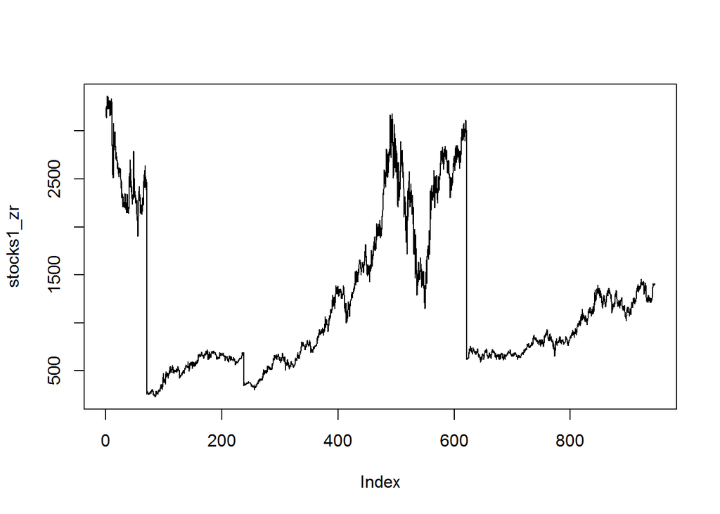

```r
plot(stocks1_zr)
```

### Seasonal trend decompostion

```r
seasonaldecom <- stl(stocks1_zr,s.window = "periodic")
seasonaldecom
```

[output not shown]

[output cut: 4676 more lines]

[output not shown]

### Plotting the Seasonal trend decompostion

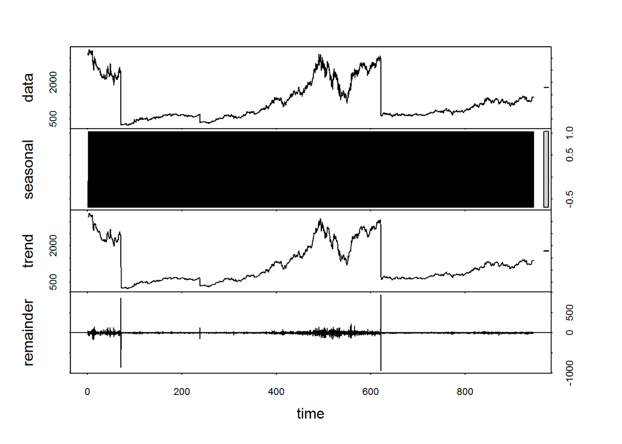

```r
plot(seasonaldecom)
```

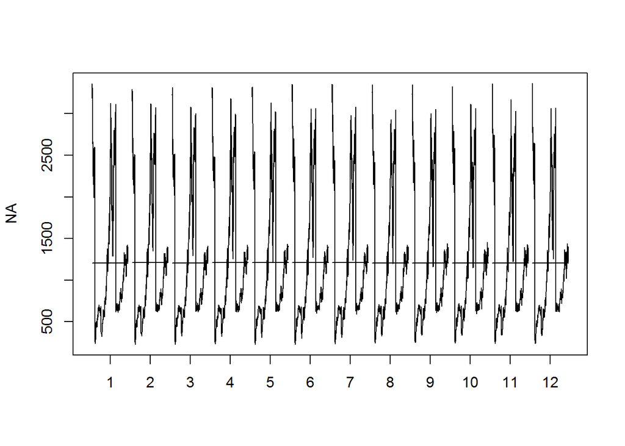

```r
monthplot(stocks1_zr)
```

Can infer that;

- There exists seasonality and trend in data
- However seasonality has very less effect compared to trend

### Initialize the results table

```r
results <- NULL
results <- data.frame()
```

### Simple Moving Average

```r
#install.packages('smooth')
library(smooth)
```

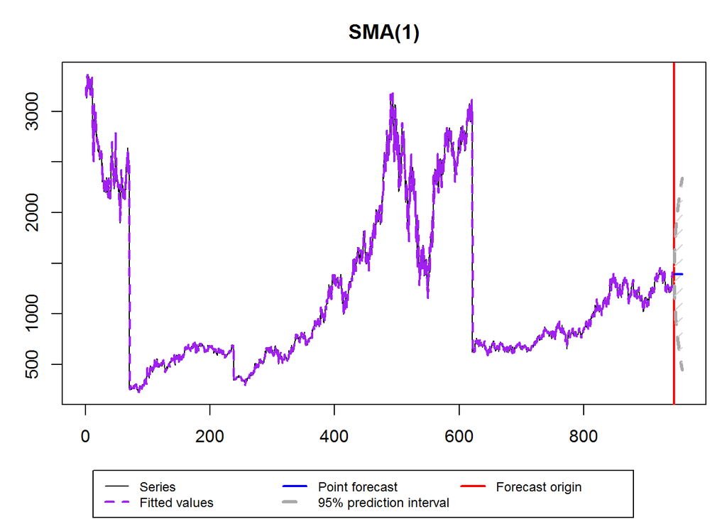

```r
SMAi <- sma(stocks1_zr, h=65,silent="graph")
#forecasting

plot(forecast(SMAi,h=65))
```

```r
# Accuracy

temp <- list(sqrt(SMAi$cf))
temp <- as.data.frame(temp,col.names = 'RMSE', row.names = 'SMA')

results <- rbind(results,temp)

results['SMA',]
```

```
## [1] 59.85817
```

Can infer that:

- RMSE for the model is 59.85817

### Single exponential smoothing

### Holt-Winters exponential smoothing without trend and without seasonal component.

```r
SES_Auto <- HoltWinters(stocks1_zr,beta = FALSE,gamma=FALSE)
SES_Auto
```

```
## Holt-Winters exponential smoothing without trend and without seasonal component.
##
## Call:
## HoltWinters(x = stocks1_zr, beta = FALSE, gamma = FALSE)
##
## Smoothing parameters:
##  alpha: 0.9999239
##  beta : FALSE
##  gamma: FALSE
##
## Coefficients:
##       [,1]
## a 1394.101
```

```r
SES_Auto_forcast <- forecast(SES_Auto,h=65)

# Accuracy

temp <- list(accuracy(SES_Auto_forcast)[,'RMSE'])
temp <- as.data.frame(temp,col.names = 'RMSE', row.names = 'SES')

results <- rbind(results,temp)

results['SES',]
```

```
## [1] 59.86455
```

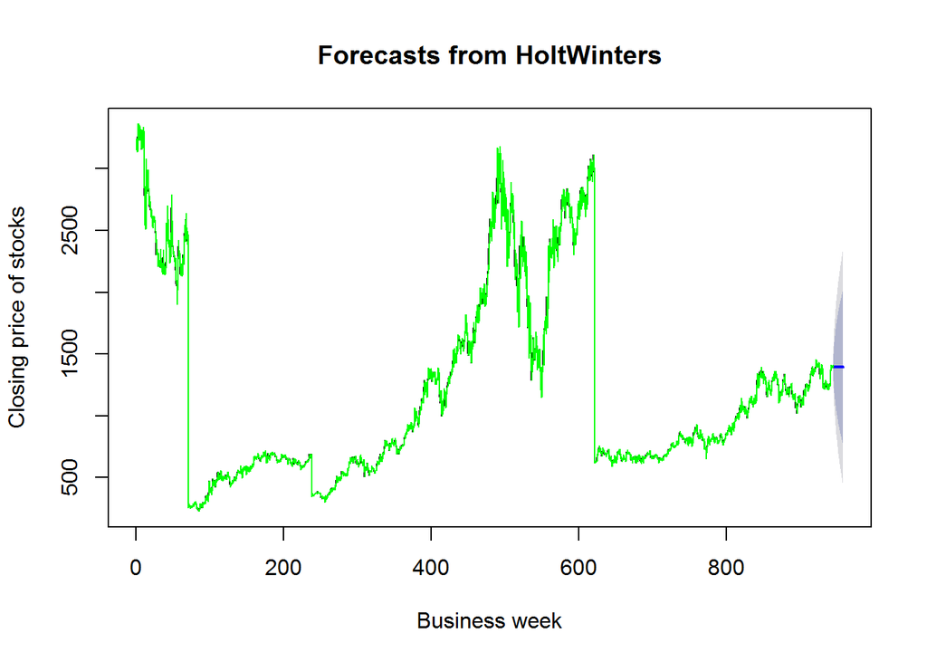

```r
# Plot the graph

plot(SES_Auto_forcast,xlab='Business week',ylab='Closing price of stocks')
lines(SES_Auto_forcast$fitted,col='green')
```

Can infer that:

- RMSE for the model is 59.86455

### Double exponential smoothing

### Holt-Winters exponential smoothing with trend and without seasonal component.

```r
DES_Auto <- HoltWinters(stocks1_zr,gamma=FALSE)
DES_Auto
```

```
## Holt-Winters exponential smoothing with trend and without seasonal component.
##
## Call:
## HoltWinters(x = stocks1_zr, gamma = FALSE)
##
## Smoothing parameters:
##  alpha: 1
##  beta : 0.0178239
##  gamma: FALSE
##
## Coefficients:
##          [,1]
## a 1394.100000
## b    1.451342
```

```r
DES_Auto_forcast <- forecast(DES_Auto,h=65)

# Accuracy

temp <- list(accuracy(DES_Auto_forcast)[,'RMSE'])
temp <- as.data.frame(temp,col.names = 'RMSE', row.names = 'DES')

results <- rbind(results,temp)

results['DES',]
```

```
## [1] 60.53214
```

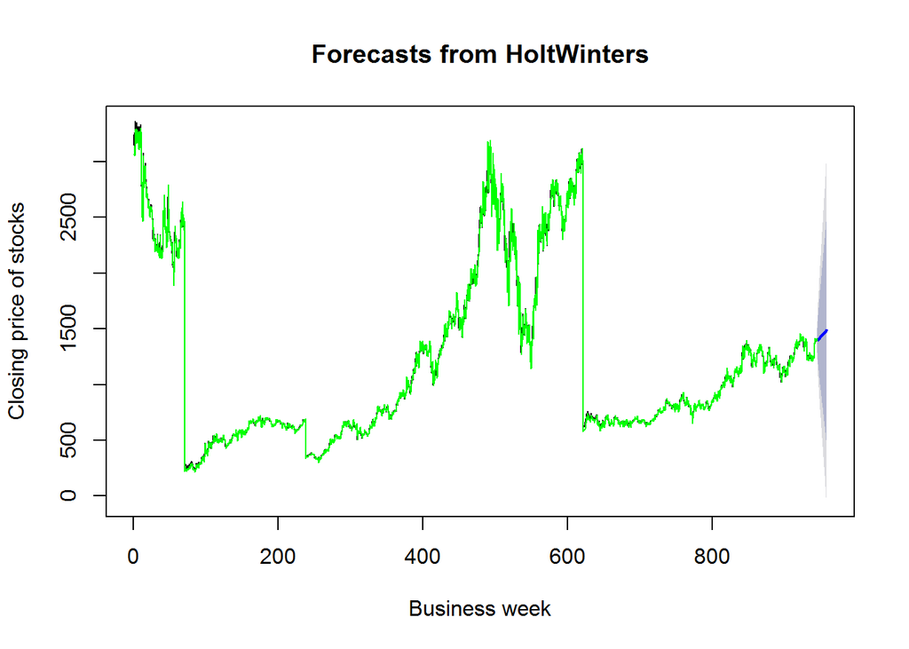

```r
# Plot the graph

plot(DES_Auto_forcast,xlab='Business week',ylab='Closing price of stocks')
lines(DES_Auto_forcast$fitted,col='green')
```

Can infer that:

- RMSE for the model is 60.53214

### Triple exponential smoothing

### Holt-Winters exponential smoothing with trend and additive seasonal component.

```r
TES_Auto <- HoltWinters(stocks1_zr)
TES_Auto
```

```
## Holt-Winters exponential smoothing with trend and additive seasonal component.
##
## Call:
## HoltWinters(x = stocks1_zr)
##
## Smoothing parameters:
##  alpha: 0.9827015
##  beta : 0.001283141
##  gamma: 1
##
## Coefficients:
##            [,1]
## a  1403.1520221
## b     0.2839576
## s1   -9.0272542
## s2  -11.4448454
## s3   -9.0378501
## s4  -10.1321624
## s5   -9.0520221
```

```r
TES_Auto_forcast <- forecast(TES_Auto,h=65)

# Accuracy

temp <- list(accuracy(TES_Auto_forcast)[,'RMSE'])
temp <- as.data.frame(temp,col.names = 'RMSE', row.names = 'TES_Add')

results <- rbind(results,temp)

results['TES_Add',]
```

```
## [1] 60.90787
```

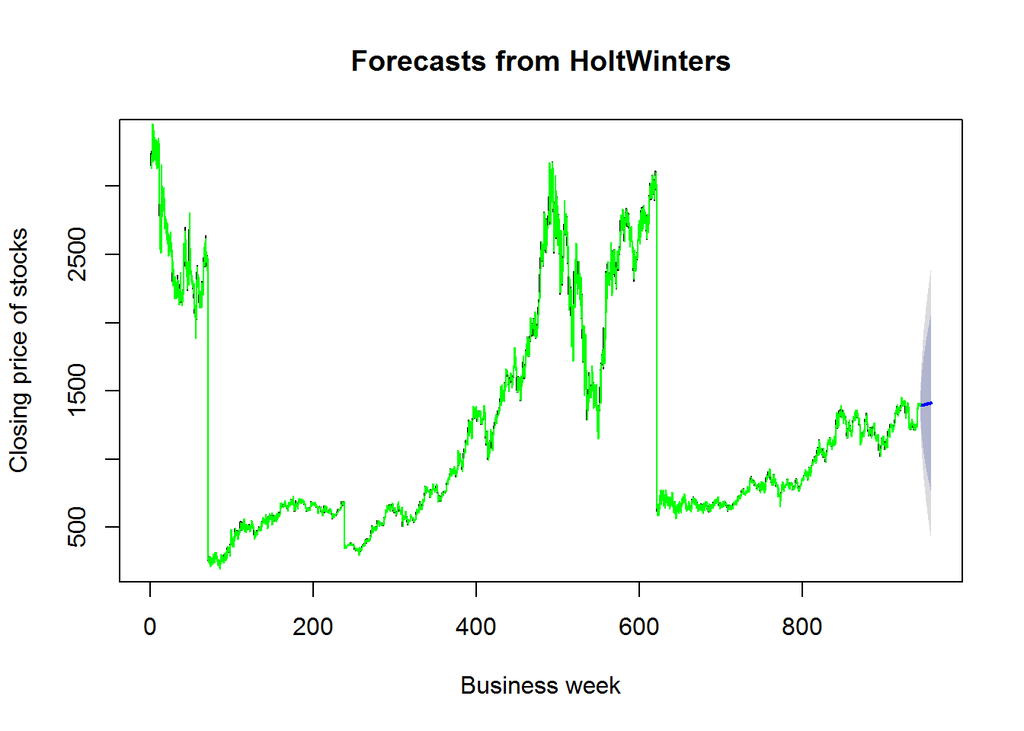

```r
# Plot the graph

plot(TES_Auto_forcast,xlab='Business week',ylab='Closing price of stocks')
lines(TES_Auto_forcast$fitted,col='green')
```

Can infer that:

- RMSE for the model is 60.90787

### ARIMA (Auto regressive Integrated Moving Average)

```r
ARIMA_model <- auto.arima(stocks1_zr)
summary(ARIMA_model)
```

```
## Series: stocks1_zr
## ARIMA(0,1,0) with drift
##
## Coefficients:
##         drift
##       -0.3910
## s.e.   0.8713
##
## sigma^2 estimated as 3584:  log likelihood=-26017.44
## AIC=52038.87   AICc=52038.87   BIC=52051.79
##
## Training set error measures:
##                       ME     RMSE      MAE        MPE     MAPE      MASE
## Training set 0.000686243 59.85691 21.95222 -0.1851193 1.940941 0.4238227
##                     ACF1
## Training set 0.009821988
```

```r
ARIMA_model_forcast <- forecast(ARIMA_model,h=65)

# Accuracy

temp <- list(accuracy(ARIMA_model_forcast)[,'RMSE'])
temp <- as.data.frame(temp,col.names = 'RMSE', row.names = 'ARIMA')

results <- rbind(results,temp)

results['ARIMA',]
```

```
## [1] 59.85691
```

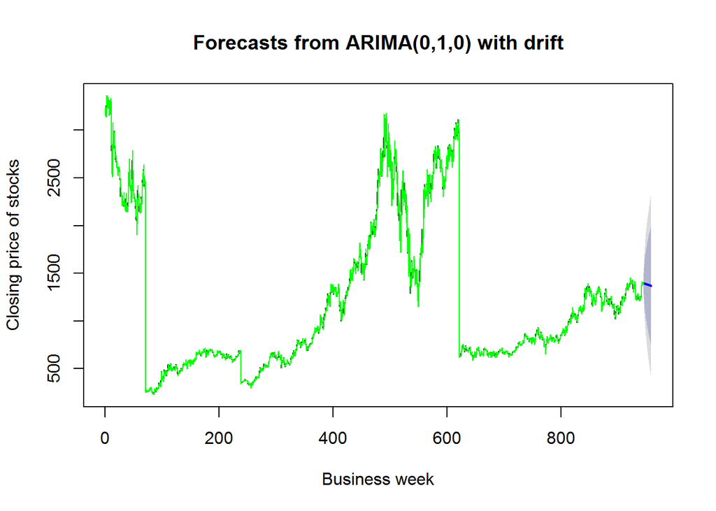

```r
# Plot the graph

plot(ARIMA_model_forcast,xlab='Business week',ylab='Closing price of stocks')
lines(ARIMA_model_forcast$fitted,col='green')
```

Can infer that:

- RMSE for the model is 59.85691

### Comparing the various time series models

```r
results
```

```
##             RMSE
## SMA     59.85817
## SES     59.86455
## DES     60.53214
## TES_Add 60.90787
## ARIMA   59.85691
```

```r
idx <- which(results==min(results))
cat('The model selected as the best one is:',row.names(results)[idx],'\nThe RMSE for the model is:',min(results))
```

```
## The model selected as the best one is: ARIMA
## The RMSE for the model is: 59.85691
```

### Create file with final prediction values from the best model

```r
write.csv(ARIMA_model_forcast$mean,"HDFC_forecast_3months.csv")
ARIMA_model_forcast$mean
```

```
## Time Series:
## Start = c(945, 3)
## End = c(958, 2)
## Frequency = 5
##  [1] 1393.709 1393.318 1392.927 1392.536 1392.145 1391.754 1391.363
##  [8] 1390.972 1390.581 1390.190 1389.799 1389.408 1389.017 1388.626
## [15] 1388.235 1387.844 1387.453 1387.062 1386.671 1386.280 1385.889
## [22] 1385.498 1385.107 1384.716 1384.325 1383.934 1383.543 1383.152
## [29] 1382.761 1382.370 1381.979 1381.588 1381.197 1380.806 1380.415
## [36] 1380.024 1379.633 1379.242 1378.851 1378.460 1378.069 1377.678
## [43] 1377.287 1376.896 1376.505 1376.114 1375.723 1375.332 1374.941
## [50] 1374.550 1374.159 1373.768 1373.377 1372.986 1372.595 1372.204
## [57] 1371.813 1371.422 1371.031 1370.640 1370.248 1369.857 1369.466
## [64] 1369.075 1368.684
```

### Conclusion:

- These are predicted values for next 3 months which are having 65 business days
- It is forecasted that closing stock prices will decrease and strategies need to be planned accordingly.